# Can a small deep model beat a twenty-year-old spectral index, without pretending the labels are truth?

## How wrong could it be? Per-pixel uncertainty and conformal severity sets

A calibrated probability (previous section) tells you whether *0.7 means 70%*. It does not tell you, pixel by pixel, **where the model is guessing**. Two tools close that gap, and both are honest about a model that has never seen this island.

First, **Monte-Carlo dropout**: the event-wise U-Net carries a dropout layer before its head, so if we keep dropout *on* and run the scene through `T` times, the spread of the predictions is a cheap Bayesian posterior. We split it into *aleatoric* uncertainty (irreducible data noise) and **epistemic** uncertainty (*what the model does not know*, the part more or better-matched training data could fix). Epistemic uncertainty is the one that should worry an operator.

Second, **conformal prediction**: instead of one class per pixel, emit a *set* of classes guaranteed (distribution-free) to contain the truth at a chosen rate. Where the model is sure, the set is a singleton; where it is lost, the set grows.

```
2026-07-01 02:36:04 | INFO    | src.evaluation.uq_report | MC-dropout: T=8 tile=256 stride=256 on kangaroo_island_2019_2020 (2317, 4270)
```

```
2026-07-01 02:36:26 | INFO    | src.evaluation.uq_report | activated 1 dropout module(s)
```

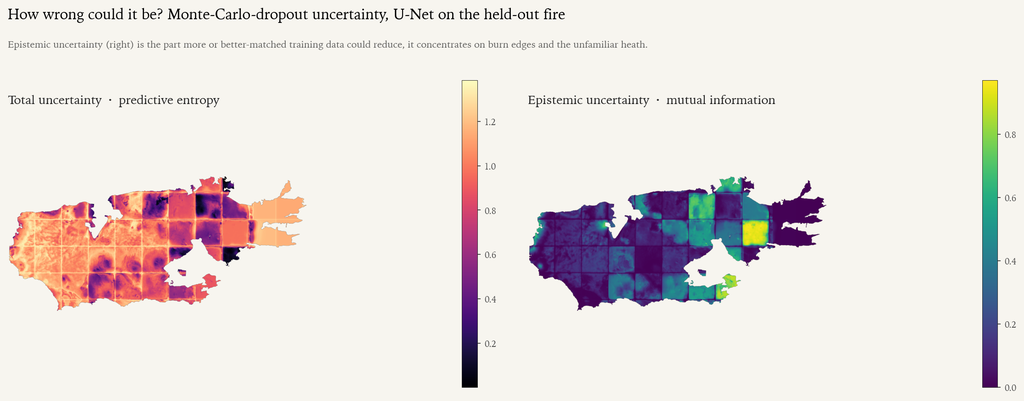

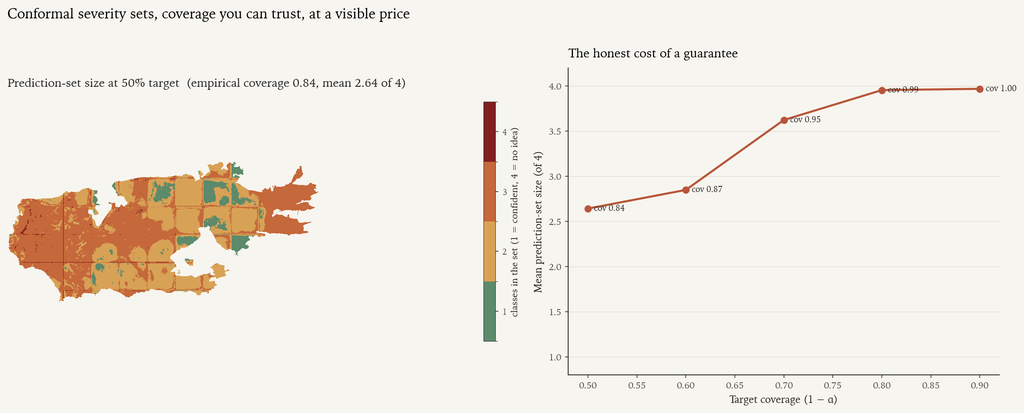

```
Mean epistemic (model) uncertainty: 0.201 nats
Conformal efficiency, target coverage -> empirical coverage, mean set size:
  50%  ->  cov 0.838   set size 2.64 / 4
  60%  ->  cov 0.866   set size 2.85 / 4
  70%  ->  cov 0.947   set size 3.62 / 4
  80%  ->  cov 0.993   set size 3.95 / 4
  90%  ->  cov 0.996   set size 3.97 / 4
```

```python
# --- Per-pixel uncertainty (MC-dropout) + conformal sets ---------------------
from src.evaluation.uq_report import compute_uq, fig_entropy, fig_conformal

uq = compute_uq("kangaroo_island_2019_2020", T=8, alpha=0.1)
fig_entropy(uq, _FIGDIR / "10_entropy_map.png")
fig_conformal(uq, _FIGDIR / "11_conformal_sets.png")
display(Image(filename=str(_FIGDIR / "10_entropy_map.png")))
display(Image(filename=str(_FIGDIR / "11_conformal_sets.png")))

print(f"Mean epistemic (model) uncertainty: {uq['mean_epistemic_mi']:.3f} nats")
print("Conformal efficiency, target coverage -> empirical coverage, mean set size:")
for _s in uq["conformal_sweep"]:
    print(f"  {_s['target_coverage']:.0%}  ->  cov {_s['empirical_coverage']:.3f}"
          f"   set size {_s['mean_set_size']:.2f} / 4")
```

Read both panels honestly. Epistemic uncertainty concentrates exactly where you would expect a transferred model to struggle, burn-boundary pixels and the heath that looks nothing like the NSW eucalypt forests it trained on. And the conformal efficiency curve is humbling: to *guarantee* 90% coverage this model must emit nearly **all four** severity classes per pixel (mean set size ≈ 4). It is not separating severity under transfer; it is hedging.

That is not a failure of the method, it is the method doing its job. A system that reports "high severity, but my set also includes very-high and moderate" is telling an ecologist the truth: *don't quote this pixel without a field check*. For a platform whose outputs become decision-grade figures, a calibrated "I don't know" is worth more than a confident wrong answer, and conformal sets plus epistemic maps are how you ship one.

## From pixels to management units

Everything so far has been a raster. But the people who *act* on a burn-severity map, rehabilitation teams, biodiversity officers, tenure managers, work in vectors and hectares-per-parcel, not pixels. The last step is the one that makes the model's output decision-grade: **polygonise** the severity map, **overlay** it on the management units, and roll up burnt hectares per unit. Here the units are a 5 km grid stand-in; in production they are bioregion or tenure polygons.

The same operation scales in PostGIS, `ST_Intersection` clips severity to each unit, `ST_Area` sums it, `ST_Union` dissolves the burnt footprint (`sql/queries.sql`), and the layers carry a QGIS style (`qgis/burn_severity.qml`) so the cartography matches every figure in this notebook.

```
2026-07-01 02:36:29 | INFO    | src.geospatial.report | vectorised 4 class polygons; 144 management units; burnt classes=['High', 'Low–Moderate', 'Unburnt', 'Very High', 'severe_ha']
```

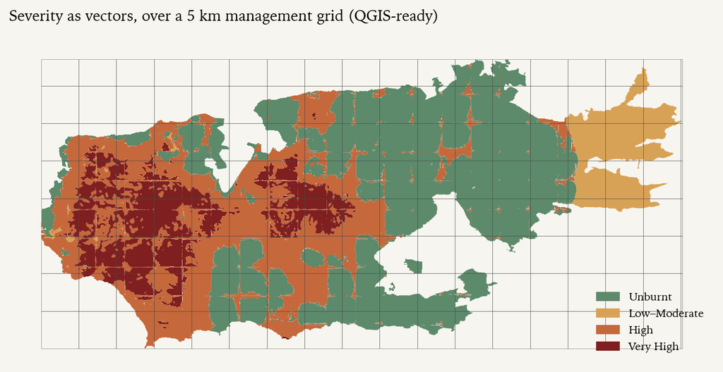

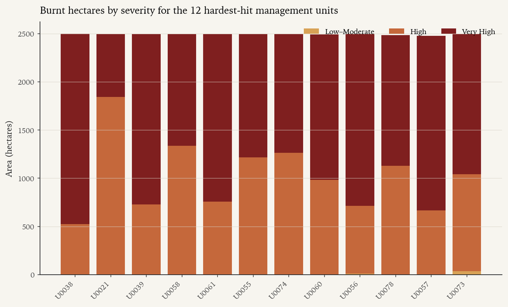

```
Severity area over the GEEBAM-assessed footprint:
  class_name  area_ha  pct
     Unburnt  84603.8 46.9
Low–Moderate  14569.0  8.1
        High  56728.1 31.4
   Very High  24480.1 13.6
```

```python
# --- Pixels -> polygons -> management-unit roll-up ---------------------------
from src.geospatial.report import compute_vector_report, fig_severity_map, fig_unit_areas

vec = compute_vector_report("kangaroo_island_2019_2020", cell_m=5000.0)
fig_severity_map(vec, _FIGDIR / "12_qgis_map.png")
fig_unit_areas(vec, _FIGDIR / "13_mgmt_unit_areas.png")
display(Image(filename=str(_FIGDIR / "12_qgis_map.png")))
display(Image(filename=str(_FIGDIR / "13_mgmt_unit_areas.png")))

print("Severity area over the GEEBAM-assessed footprint:")
print(vec["summary"][["class_name", "area_ha", "pct"]].round(1).to_string(index=False))
```

Two honest notes. The polygons are clipped to the **GEEBAM-assessed footprint** (`valid_mask_path` = the label), without that, the model happily labels open ocean as "unburnt" and the hectares are meaningless; clipping is the difference between a real number and a plausible-looking wrong one. And the per-unit bars are ranked by *severe* (High + Very-High) area, because that, not total burnt area, is what triages a rehabilitation programme. This raster→vector→database path, with metric CRS handling throughout, is the geospatial-engineering spine the rest of the modelling hangs on.

## From a laptop to a continent: throughput, memory and cost

A model that works on one island has to survive being pointed at a continent. The platform questions are concrete and measurable: **pixels per second**, **peak memory**, and therefore the **cloud cost** to map a whole state. Here is the event-wise U-Net benchmarked on this machine (Apple MPS vs CPU), with the measured throughput projected onto an 80 Mha state at 0.5 m aerial resolution, the kind of job an enterprise ecology platform actually runs.

```
2026-07-01 02:36:40 | INFO    | src.inference.batch_infer | mps  kangaroo_island_2019_2020    9893590 px in 8.9s = 1112339 px/s, peak 6615 MB
```

```
2026-07-01 02:37:00 | INFO    | src.inference.batch_infer | cpu  kangaroo_island_2019_2020    9893590 px in 18.8s = 525231 px/s, peak 6021 MB
```

```
2026-07-01 02:37:01 | INFO    | src.inference.scale_report | logged 3 runs to MLflow store at outputs/mlruns
```

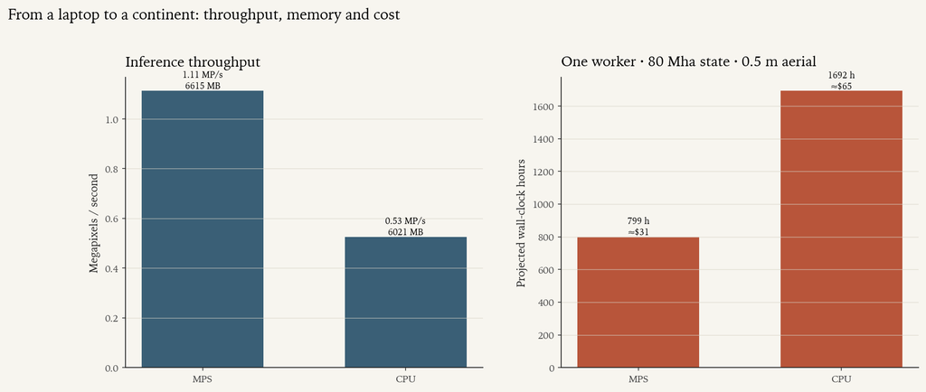

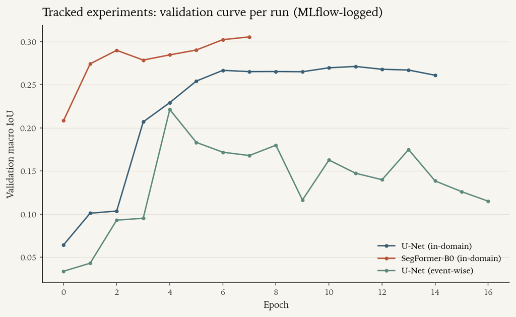

```
device  px_per_s  peak_rss_mb  proj_hours_state  proj_usd_state
   mps   1112339       6614.7             799.1           30.85
   cpu    525231       6021.4            1692.4           65.33
```

```python
# --- Scale benchmark + experiment tracking ----------------------------------
import torch
from src.inference.scale_report import render_all as scale_render

_devs = ["mps", "cpu"] if torch.backends.mps.is_available() else ["cpu"]
scale = scale_render(_FIGDIR, devices=_devs)   # also backfills MLflow at outputs/mlflow.db
display(Image(filename=str(_FIGDIR / "14_scale_benchmark.png")))
display(Image(filename=str(_FIGDIR / "15_mlflow_runs.png")))

print(scale["benchmark_df"][["device", "px_per_s", "peak_rss_mb",
                             "proj_hours_state", "proj_usd_state"]].to_string(index=False))
```

## Foundation models: does Prithvi-EO-2.0 beat a from-scratch U-Net?

Every learned model so far was trained from scratch on these four fires. The emerging alternative is a **geospatial foundation model**, pre-trained on global satellite imagery, then adapted to the task. We take **Prithvi-EO-2.0-300M** (NASA/IBM), whose six expected bands are exactly our composite bands, **freeze the entire 304M-parameter backbone**, and train only a small decoder (~2.6M params) on top, a linear-probe-style adaptation, not a full fine-tune. It sees only the single post-fire image: none of the engineered pre/post/ΔNBR features the other models get. (Reproduce with `python -m src.models.train_prithvi`.)

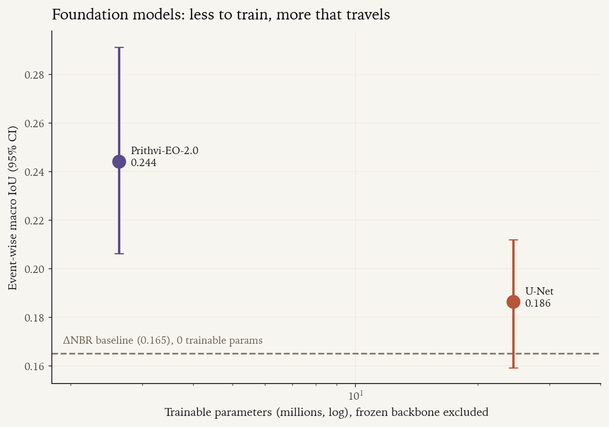

```
Prithvi-EO-2.0 event-wise macro-IoU: 0.244  95% CI [0.206, 0.291]
vs ΔNBR baseline: Δ = +0.059  95% CI [+0.031, +0.082]  p = 0.000
```

```python
# --- Foundation model: Prithvi-EO-2.0 frozen-backbone probe ------------------
import json
from src.evaluation.uncertainty_report import fig_foundation

_rep = json.loads((REPO_ROOT / "outputs" / "metrics" / "uncertainty"
                   / "kangaroo_island_2019_2020_eventwise.json").read_text())
fig_foundation(_rep, _FIGDIR / "16_prithvi_vs_unet.png")
display(Image(filename=str(_FIGDIR / "16_prithvi_vs_unet.png")))

_p = _rep["models"]["prithvi"]["bootstrap"]["metrics"]["macro_iou"]
_d = _rep["paired_delta_vs_dnbr"]["prithvi"]
print(f"Prithvi-EO-2.0 event-wise macro-IoU: {_p['point']:.3f}  "
      f"95% CI [{_p['ci_low']:.3f}, {_p['ci_high']:.3f}]")
print(f"vs ΔNBR baseline: Δ = {_d['delta']:+.3f}  "
      f"95% CI [{_d['ci_low']:+.3f}, {_d['ci_high']:+.3f}]  p = {_d['p_value']:.3f}")
```

This is the result that earns the experiment. The frozen foundation model, with a tenth of the trainable parameters and **none** of the hand-built change features, scores the highest event-wise macro-IoU of any method, and, applying the same spatial-block bootstrap as before, its margin over ΔNBR is **statistically significant** (the CI on the difference clears zero), where the from-scratch U-Net's was not. The pre-trained representation simply *travels* across biomes better than features learned from four fires.

The honest caveats keep it grounded: this is a single-frame, frozen-backbone probe; a temporal (pre+post) input and an unfrozen fine-tune would almost certainly do better, and the labels are still a proxy. But the direction is clear, and it is the right direction for a platform that has to generalise to new landscapes with scarce labels, which is the whole game in ecological monitoring.

A representation pre-trained on the whole planet travelled to an unseen Australian island better than features learned from four fires, with a tenth of the trainable weights. For monitoring problems where labels are scarce and every new site is out-of-domain, that is the whole game.

## Three honest takeaways from the benchmark

**1. Put error bars on the claim, and most of the claim disappears.** ΔNBR with USGS thresholds is a hard floor. With a spatial-block bootstrap that respects autocorrelation, the from-scratch U-Net's edge over it is **not statistically significant** (Δ macro-IoU ≈ +0.02, 95% CI spans 0, p ≈ 0.06). A naive McNemar over nine million pixels calls every difference significant; it is wrong, because the pixels are not independent. Reporting a point estimate without that correction would have over-claimed, and the whole job is to not over-claim.

**2. The foundation model is the one that clears the bar.** A *frozen* Prithvi-EO-2.0 (304M params, only a 2.6M-param decoder trained, fed only the post-fire image with none of the engineered Δ-features) reaches the highest event-wise macro-IoU, and its margin over ΔNBR **is** significant (Δ +0.059, 95% CI [+0.03, +0.08]). Representations pre-trained on global imagery travel across biomes better than features learned from four fires, the right bet for a platform that must generalise to new landscapes with scarce labels.

**3. The label problem dominates the model problem.** AUS GEEBAM is the best public severity product Australia has, and it is a satellite-derived proxy. Every number here measures how well a model learned a particular algorithmic interpretation of the physics, not the physics. The response is engineering humility made concrete: event-wise hold-out, calibration (ECE/Brier), **conformal prediction sets**, **design-based area-adjusted accuracy**, **confounder-controlled error analysis**, and per-pixel **uncertainty**, never the words “ground truth.”

The point was never the win. It is the discipline around it, trustworthy figures with confidence intervals, uncertainty you can act on, a vector→PostGIS roll-up an ecologist can use, and a throughput/cost budget for running it at landscape scale. That discipline is portable to any satellite- or drone-derived classification problem, which is exactly the point.

**Project repository:** all code and configs are in this repository under `src/` and `configs/`. The README ships a runnable quickstart for the full pipeline (data fetch → composite → tile → train → evaluate → render) on a single AOI in < 2 hours wall-clock on Apple Silicon.  
**Non-operational notice:** this work is research and education only. It is not for emergency response, public warning, dispatch, evacuation planning, insurance assessment, or any safety-of-life decision. See `docs/model_card.md` for the full limitations list.  
**Attribution:** Contains modified Copernicus Sentinel data [2018–2020] processed by ESA. AUS GEEBAM © Commonwealth of Australia 2020, licensed CC-BY 4.0. NIAFED v20200225 © Commonwealth of Australia 2020, licensed CC-BY 4.0.